# Explore and Summarize Data With R

**pH vs. Volatile Acidity over Quality**

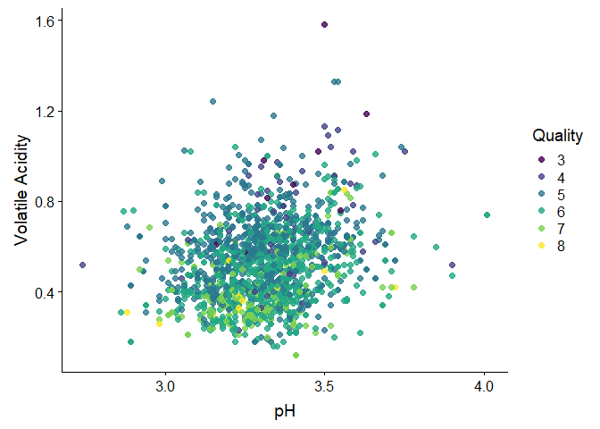

From the plot we can see high quality wines when the wine have volatile acidity less than 0.9 and pH less than 3.7. and low quality wines when the wine have pH between 3.2 and 3.7 and volatile acidity above 0.7.

**Density vs. Volatile Acidity over Quality**

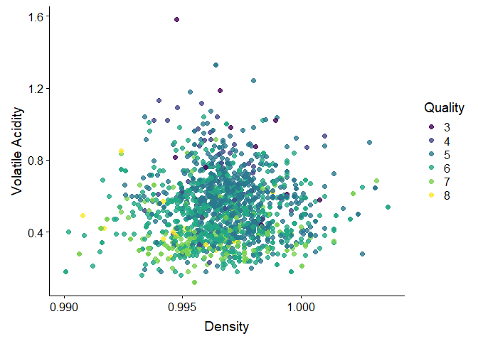

From the plot we can see high quality wines when the wine have density less than 0.998 and volatile acidity less 0.9. and low quality wines when the wine have density between 0.994 and 1.002 and volatile acidity above 0.4 .

**Citric Acid vs. Fixed Acidity over Volatile Acidity**

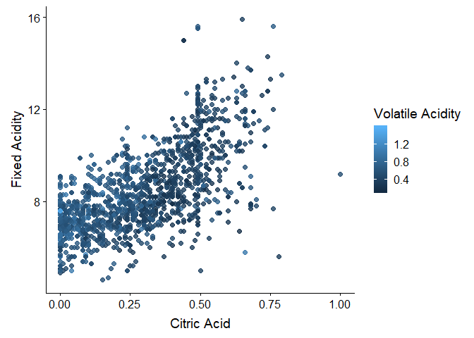

**Density vs. Fixed Acidity over Citric Acid**

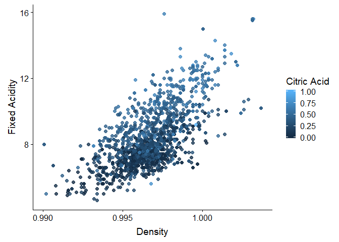

From the plot we can see the higher Density and Fixed Acidity in the wine, The higher Citric Acid get in wine. and the lower Density and Fixed Acidity in the wine, The lower Citric Acid get in wine.

**Alcohol vs. Density over Fixed Acidity**

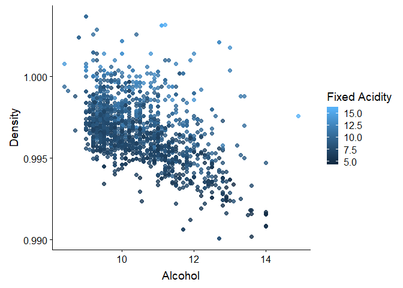

From the plot we can see Higher alcohol and lower density in the wine, Led to lower Fixed Acidity in wine. Lower alcohol and higher density in the wine, Led to higher Fixed Acidity in wine.

**pH vs. Citric Acid over Fixed Acidity**

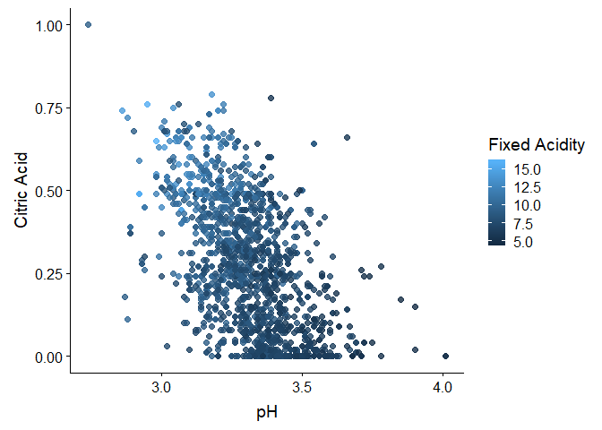

From the plot we can see Higher fixed acidity in wine when pH less than 3.4 and citric acid less than 0.78. lower fixed acidity in wine when pH above 3.4 and citric acid less than 0.78.

**pH vs. Citric Acid over Volatile Acidity**

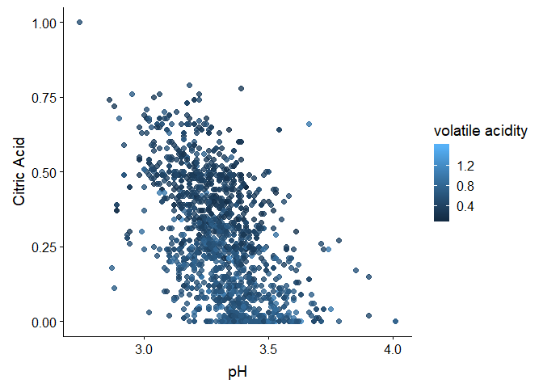

**pH vs. Fixed Acidity over Density**

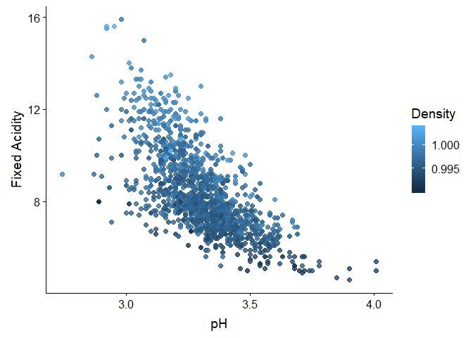

# Multivariate Analysis

After investigating many multivariate plots, We found quality will be higher in wine when we combined these properties:

- Alcohol is high.
- Volatile acidity is low.
- Density less than 1.
- Ctric acid less than 0.75.
- Sulphates between 0.6 and 1.3.

**Were there any interesting or surprising interactions between features?**

Since i did’t had a big background in the wine field every relationship between features was a surprising and interesting relationship.

# Final Plots and Summary

**Plot One : Quality Of Wine**

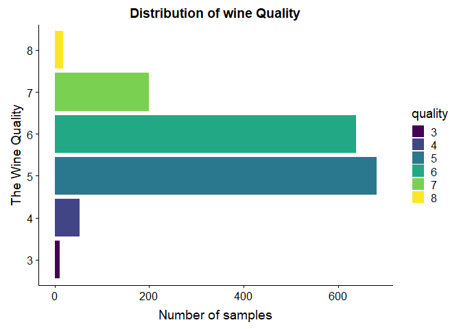

```
##   3   4   5   6   7   8
##  10  53 681 638 199  18
```

**Description One**

**what the most common quality in the dataset ?**

We choose This plot to see that the dataset contains `1.12%` of the best quality and contains `0.62%` of the worst quality in red wine, And contains`82.5%` of the avarege quality between 5 and 6. And we want to know What factors affect the quality of wine ?

**Plot Two : Alcohol And Quality Of Wine**

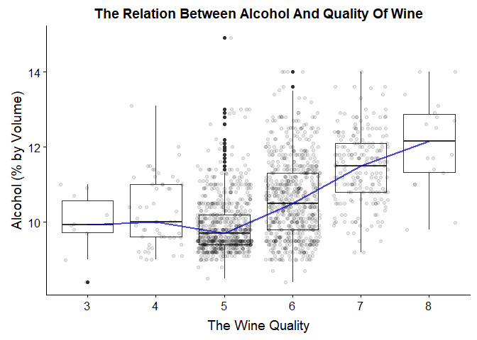

**Description Two**

Alcohol has the strongest correlation with quality which led to alcohol was the most influential factor on wine quality. Based on that we decide to choose This plot. the plot explain the relation between alcohol and quality of wine. When alcohol increses in red wine we can see the quality above 5 also increse.

**Plot Three**

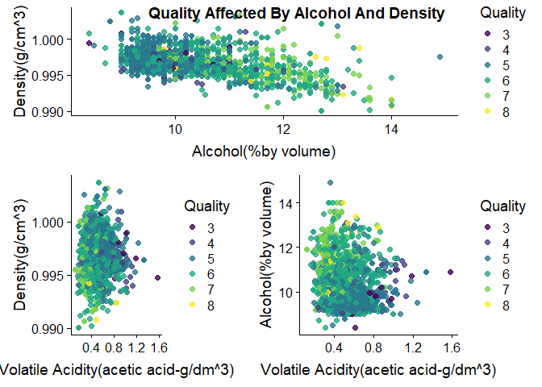

**Description Three**

We decide to choose This plot becuase we want to know the effect of other factors associated with alcohol on wine quality. We observed the opposite direction relation between quality and volatile acidity, density. And the positive relation between quality and alcohol. High quality wines when the wine have low volatile acidity and high alcohol and density less than 1. Low quality wines when the wine low alcohol and high volatile acidity and density higher than 0.994. Both of these factors are important because of their significant impact on wine quality.

# Reflection

This is a unique and intersting project. I have learned a lot through working on the project and I had many difficulties and challenges to reach the goal of the project. I spent many hours learning and building.

**What are the difficulties and challenges about this project?**

- There is no background knowledge about the wine industry.
- Which direction we should choose for our exploration.
- Interpreting the multivariate plots.

The dataset is about the red wine with 1,599 samples and 12 variables. And there’s no missing data. And it was a tidy dataset. The purpose of the project to analyze and explore the data using the plot. First we tried to understand the variables and what each variable means in this data before start to analyze them. Then we explore variables individually in Univariate Plots Section. After that we explore and analyze Binary variables the relation between them and we use correlations matrix in Bivariate Plots Section. Finally we explored the relationships between three variables in Multivariate Plots Section.

**How to improve the analysis ?**

If the number of samples was greater, The analysis would be better or if the red and white wine data were combined to study wine more and widely.

**Is there any insight for future work?**

For future work with this data we should foucse on nonlinear regression modelling for great and accurate results.

We have found a few samples with a high quality wine. This analysis can be used to raise the wine quality to achieve the best results.

In the end i really have fun analyzing this dataset with the amazing R language.

# Resource

https://www.r-bloggers.com/identify-describe-plot-and-remove-the-outliers-from-the-dataset/

https://s3.amazonaws.com/udacity-hosted-downloads/ud651/GeographyOfAmericanMusic.html

https://en.wikipedia.org/wiki/Acids_in_wine#Citric_acid

https://s3.amazonaws.com/udacity-hosted-downloads/ud651/AtlanticHurricaneTracking.html

https://statistics.laerd.com/statistical-guides/types-of-variable.php

https://s3.amazonaws.com/content.udacity-data.com/courses/ud651/diamondsExample_2016-05.html

https://stackoverflow.com/questions/3418128/how-to-convert-a-factor-to-integer-numeric-without-loss-of-information

https://support.minitab.com/en-us/minitab-express/1/help-and-how-to/modeling-statistics/regression/how-to/correlation/interpret-the-results/

https://www.dummies.com/education/math/statistics/how-to-interpret-a-correlation-coefficient-r/

http://www.sthda.com/english/wiki/visualize-correlation-matrix-using-correlogram

http://adv-r.had.co.nz/Functions.html

https://4va.github.io/biodatasci/r-viz-gapminder.html

https://cran.r-project.org/web/packages/egg/vignettes/Ecosystem.html

https://www.r-bloggers.com/producing-grids-of-plots-in-r-with-ggplot2-a-journey-of-discovery/

https://www.rdocumentation.org/packages/cowplot/versions/0.9.4/topics/plot_grid

https://rstudio-pubs-static.s3.amazonaws.com/337414_ef0db534b06a4232945a5b907cfa871a.html

https://www.rdocumentation.org/packages/ggplot2/versions/2.2.1/topics/labs

https://cran.r-project.org/web/packages/cowplot/vignettes/plot_grid.html